# Estimation of the parametric tax function

# 5 ALife data 1991-2019

## 5.1 Sample restrictions

We impose the following sample restrictions on the data.

1. $y^{taxfree}\le y\le200,000$

   Those with a negative average tax rate $t$ and those with a tax rate over 47% are excluded from the sample. The rationale for this is that the top average tax rate between 1991-2019 was either 45% or 47%. As shown in the previous section, excluding those below the tax-free threshold ensures a better fit with actual tax rates.

## 5.2 Demonstration on 2019 data

```r
A <-
  read_feather(
    here("Raw_data","LI_01_Derived_2019.feather"),
    as_data_frame = F
  ) %>%
  mutate(y=ic_taxable_income_loss) %>%
  select(pid,age,year,y,inc_tax) %>%
  collect()

Z <-
  left_join(A,CPI,by="year") %>%
  mutate(
    across(
      c(y,inc_tax),
      ~./cpi
    )
  ) %>%
  filter(inc_tax>=0&y>=0) %>%
  mutate(
    atr = if_else(y==0,0,inc_tax/y),
    x = y-inc_tax # Post-tax income needed for OLS estimation
  ) %>%
  filter(y>=0&y<=200000) %>%
  filter(atr>0&atr<=0.47)

B <-
  Z %>%
  f_estimate_tax(.,Tax_code_data_real) %>%
  mutate(tc_atr=if_else(y==0,0,tax/y), # tc_atr is tax code atr
         tc_tax=tax)

Z <-
  full_join(B,Z,by=c("pid","year","y")) %>%
  filter(y>=taxfree&atr>0)

OLS <- f_tax_lm(Z) %>% mutate(method="OLS")
NLS <- f_tax_nls(Z) %>% mutate(method="NLS")

Coefs_temp <- bind_rows(OLS,NLS)

Q <-
  Z %>%
  mutate(
    OLS = 1-OLS$value[1]*y^(-OLS$value[2]),
    NLS = 1-NLS$value[1]*y^(-NLS$value[2])
  )
```

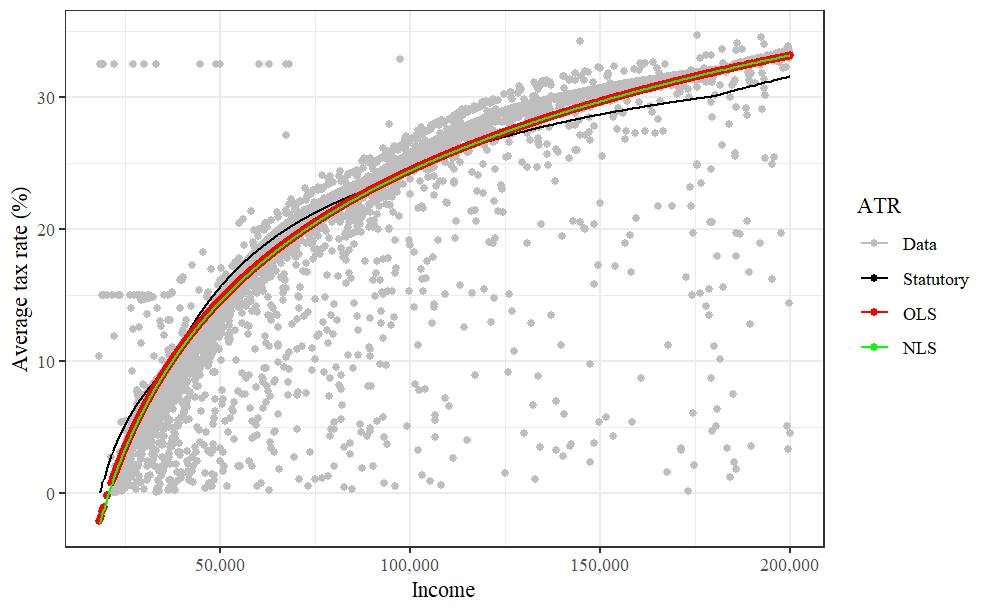

```r
QQ <-
  Q %>%
  slice_sample(prop=0.01) %>%
  select(y,atr,tc_atr,OLS,NLS) %>%
  rename(Income=y,Actual=atr,Statutory=tc_atr)

QQ %>%
  ggplot(aes(x=Income)) +
  geom_point(aes(y=Actual*100,color="Data"),show.legend = T) +
  geom_line(aes(y=Statutory*100,color="Statutory"), show.legend = T) +
  geom_point(aes(y=OLS*100,color="OLS"), show.legend = T) +
  geom_line(aes(y=NLS*100,color="NLS"), show.legend = T) +
  labs(x="Income",y="Average tax rate (%)") +
  scale_color_manual(
    name = "ATR",
    guide = 'legend',
    values = c("Data"="gray",
               "Statutory"="black",
               "OLS"="red",
               "NLS"="green")
  ) +
  scale_x_continuous(label=comma)

ggsave(
  here(results,"TP_01_ATR_OLS_NLS_Actual_2019.pdf")
)
```

## 5.3 Trend in progressivity

```r
sourceyears <- c(1991:2019)
for (i in seq_along(sourceyears)) {

    A <-
      read_feather(here("Raw_data",
                        paste0("LI_01_Derived_",sourceyears[i],".feather")),
                   as_data_frame = F) %>%
      mutate(y = ic_taxable_income_loss) %>%
      select(pid, age, year, y, inc_tax) %>%
      collect()

Z <-
  left_join(A,CPI,by="year") %>%
  mutate(
    across(
      c(y,inc_tax),
      ~./cpi
    )
  ) %>%
  filter(inc_tax>=0&y>=0) %>%
  mutate(
    atr = if_else(y==0,0,inc_tax/y),
    x = y-inc_tax # Post-tax income needed for OLS estimation
  ) %>%
  filter(y>=0&y<=200000) %>%
  filter(atr>0&atr<=0.47)

B <-
  Z %>%
  f_estimate_tax(.,Tax_code_data_real) %>%
  mutate(tc_atr=if_else(y==0,0,tax/y), # tc_atr is tax code atr
         tc_tax=tax)

Z <-
  full_join(B,Z,by=c("pid","year","y")) %>%
  filter(y>=taxfree&atr>0)

OLS <- f_tax_lm(Z) %>% mutate(method="OLS")
NLS <- f_tax_nls(Z) %>% mutate(method="NLS")

Coefs_temp <- bind_rows(OLS,NLS)

    Q1 <-
      Z %>%
      mutate(
        t = y-OLS$value[1]*y^(1-OLS$value[2]),
        x = y-t,
      ) %>%
      f_indices(.)

    Q2 <-
      Z %>%
      mutate(
        t = y-NLS$value[1]*y^(1-NLS$value[2]),
        x = y-t,
      ) %>%
      f_indices(.)

    QQ <-
      A %>%
      mutate(
        t = inc_tax,
        x = y-t
      ) %>%
      f_indices(.)

    Coefs_temp <-
      bind_rows(OLS,NLS) %>%
      mutate(Suits_est = if_else(method=="OLS",Q1$S_area[1],Q2$S_area[1]),
             Suits_data = QQ$S_area[1])

    if (i==1){
      Coefs=Coefs_temp
    }
    else{
      Coefs=bind_rows(Coefs,Coefs_temp)
    }

    print(sourceyears[i])

}

saveRDS(Coefs,here(results,"TP_01_Tau_Lambda_Suits_data.rds"))
```

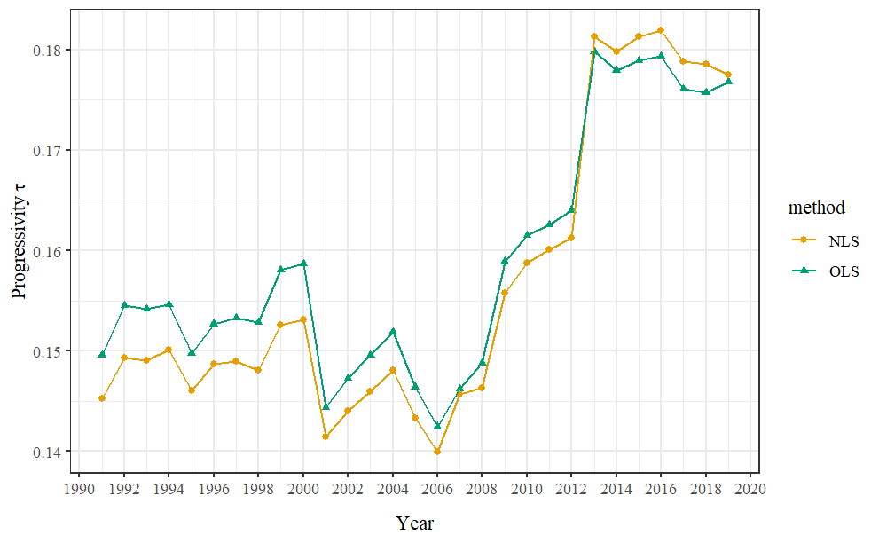

```r
X <-
  readRDS(here(results,"TP_01_Tau_Lambda_Suits_data.rds")) %>%
  filter(term=="tau")

X %>%
  ggplot(aes(x=year,y=value,color=method,shape=method)) +
  geom_point() +
  geom_line() +
 labs(
    x = "Year", y = expression(paste("Progressivity ",tau))
  ) +
  scale_x_continuous(breaks = seq(1990,2020,by=2)) +
  theme(
    axis.title.x = element_text(margin = margin(t=10)),
    axis.title.y = element_text(margin = margin(t=10))
  )

ggsave(
  here(results,"TP_01_Tau_trends_data.pdf")
)
```

## 5.4 Check if Suits index matches

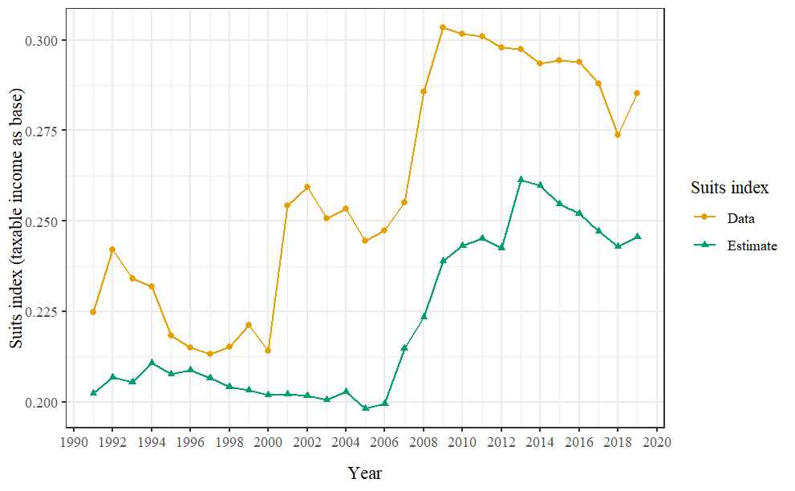

```r
X <-
  readRDS(here(results,"TP_01_Tau_Lambda_Suits_data.rds")) %>%
  filter(term=="tau"&method=="NLS") %>%
  rename(Estimate=Suits_est,Data=Suits_data) %>%
  pivot_longer(cols = c(Estimate,Data), names_to = "Suits index", values_to = "yy")


X %>%
  ggplot(aes(x=year,y=yy,color=`Suits index`,shape=`Suits index`)) +
  geom_point() +
  geom_line() +
 labs(
    x = "Year", y = "Suits index (taxable income as base)"
  ) +
  scale_x_continuous(breaks = seq(1990,2020,by=2)) +
  theme(
    axis.title.x = element_text(margin = margin(t=10)),
    axis.title.y = element_text(margin = margin(t=10))
  )

ggsave(
  here(results,"TP_01_Check_suits_index_tau_estimate.pdf")
)
```